# Every 15 minutes: Factors contributing to the illegal killing of African elephants

#### 5.1.2 Percentage of elephants dying due to poaching

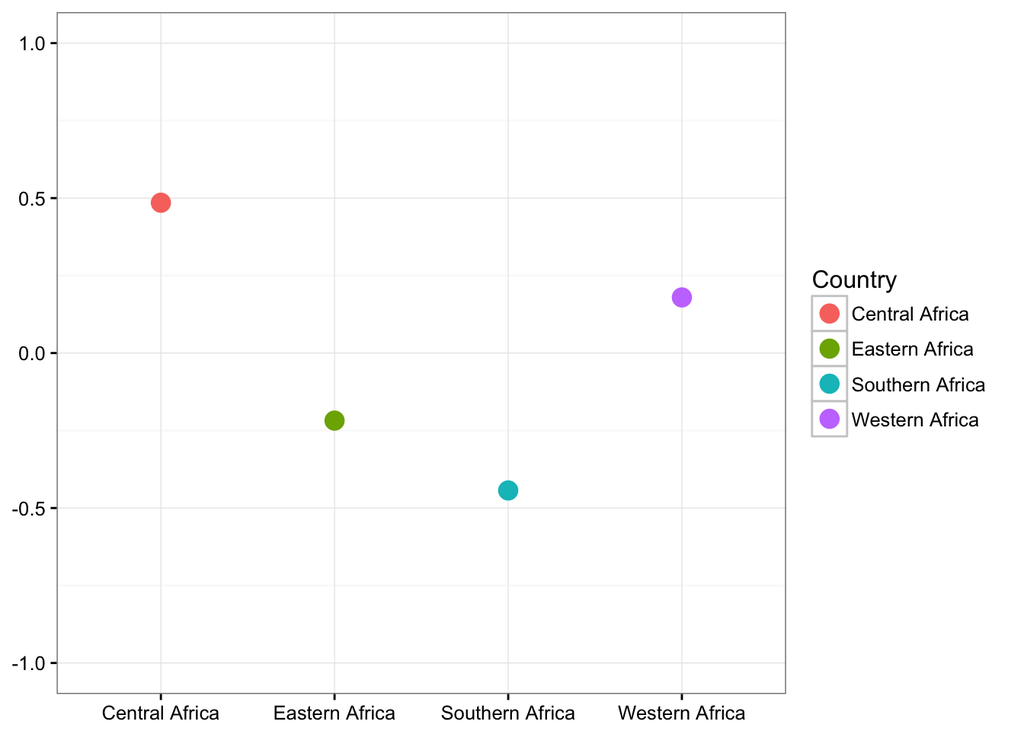

#### 5.1.3 Control of public corruption

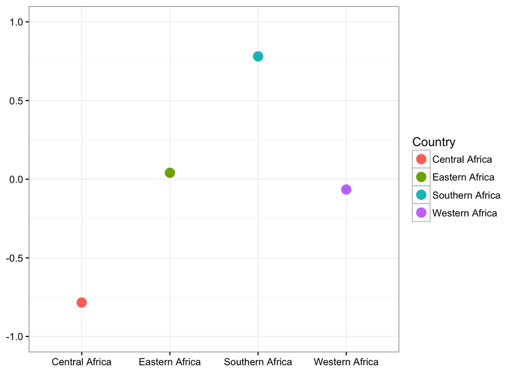

#### 5.1.4 Support for private sector development from government

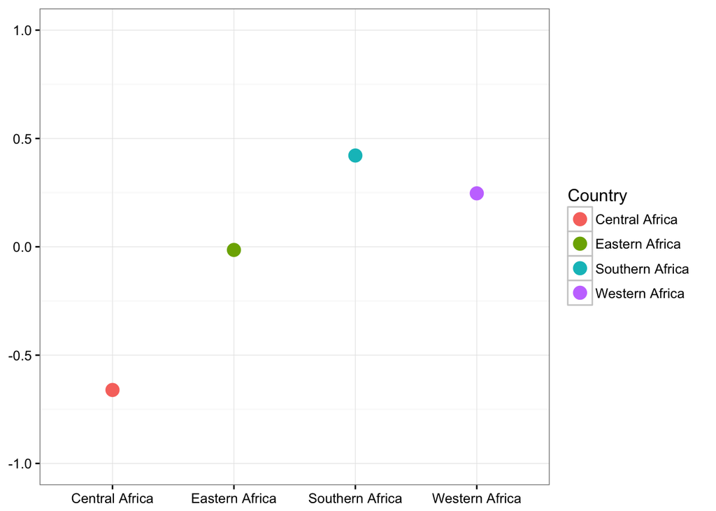

#### 5.1.5 Consumer inflation

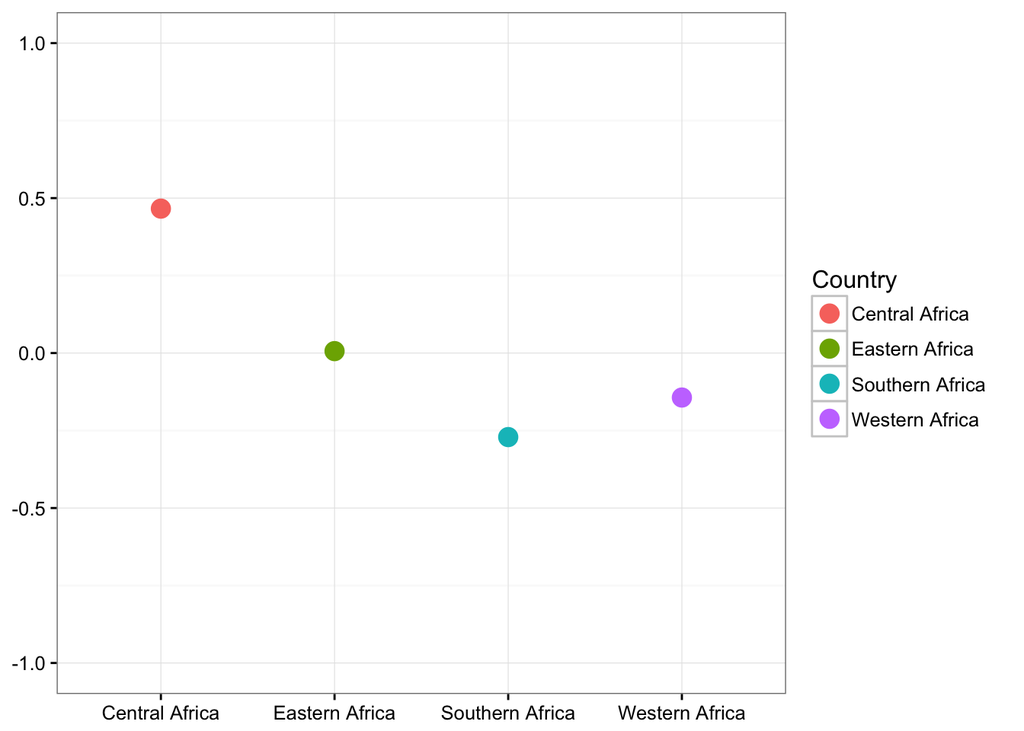

### References

Christy, B. (2012). Blood Ivory: Ivory Worship. *National Geographic*. Retrieved from http://ngm.nationalgeographic.com/2012/10/ivory/christy-text

Hsiang, S., and Sekar, N. (2016). Does Legalization Reduce Black Market Activity? Evidence from a Global Ivory Experiment and Elephant Poaching Data. *National Bureau of Economic Research*. Retrieved from http://www.nber.org/papers/w22314

Kelly, M. (2016). After legal-ivory experiment, black markets thrive from greater demand, less risk. Princeton University. Retrieved from http://www.princeton.edu/main/news/archive/S46/59/11K97/?section=topstories

Lemeiux, A. M., and Clarke, R. V. (2009). The International Ban on ivory sales and its effects on elephant poaching in Africa. *British Journal of Criminology*, 49, 451-471.